# IE360 Homework 1

In this homework, firstly, three data series from three different categories are obtained from EVDS. After that, three words that are thought to be related to these data series are determined and their search volume data is obtained from Google Trends. Lastly, the relationship (or whether there is one or not) between these data series from EVDS and seach volume data from Google Trends is examined.

As my data series, I chose USD/TRY exchange rates, interest rates on consumer loans, and consumer price index (CPI). The data series are observed at monthly level and the observations are from 10/2008-04/2021.

The R markdown file of this homework can be found [here](https://bu-ie-360.github.io/spring21-ozdemirezgi/files/HW1/IE360_HW1.Rmd)

The data series that are worked on can be found [here](https://bu-ie-360.github.io/spring21-ozdemirezgi/files/HW1/IE360_HW1_Data.zip)

## 1. USD/TRY Exchange Rates

As Turkey is a country that relies on imports heavily, many things are determined according to exchange rates, making the exchange rates an interest of not only CBRT or some companies, but also almost every person that lives in Turkey.

The keyword for this data series is *dolar*. As people can find the exchange rates only by searching for the target currency, no other words were added.

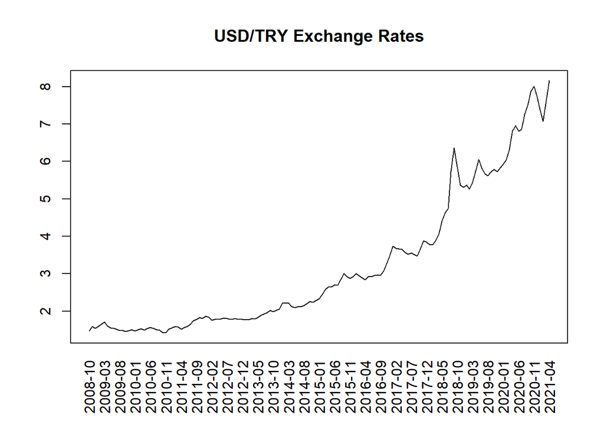

```r
library(readxl)
EVDS <- read_excel("C:\\Users\\Ezgi-Pc\\Desktop\\EVDS_data.xlsx")
usd_try <- unlist(EVDS[2])
names(usd_try) <- NULL
usd_try <- as.numeric(usd_try[-(152:181)])

setwd("C:/Users/Ezgi-Pc/Desktop")
google_usd <- read.csv(file = 'usd_try.csv')
google_usd <- unlist(google_usd)
names(google_usd) <- NULL
google_usd <- as.numeric(google_usd)

x_axis <- unlist(EVDS[1])
names(x_axis) <- NULL
x_axis <- x_axis[-(152:181)]


plot(usd_try, type = "l", xaxt = "n", xlab = " ", ylab = " ", main = "USD/TRY Exchange Rates")
axis(side = 1, labels = x_axis, at = 1:151, tick = FALSE, las = 2)
```

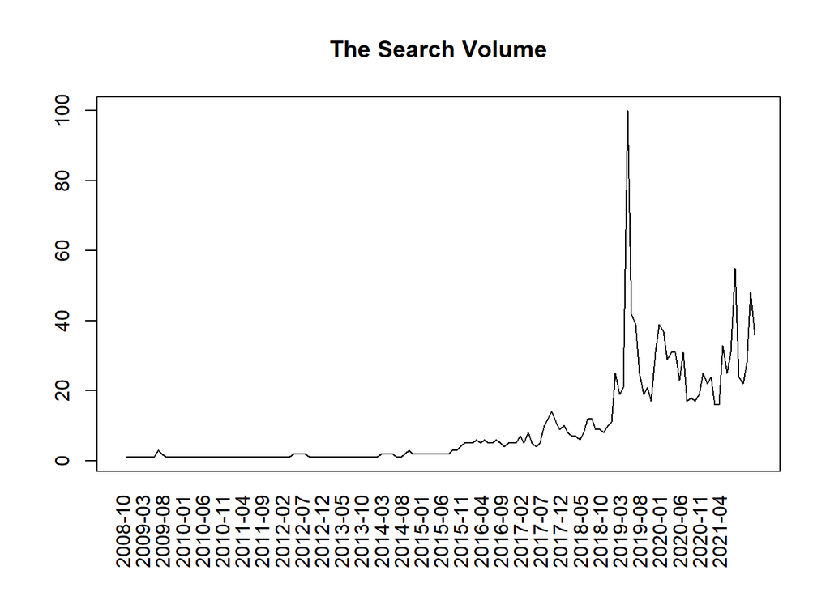

```r
plot(google_usd, type = "l", xaxt = "n", xlab = " ", ylab = " ", main = "The Search Volume")
axis(side = 1, labels = x_axis, at = 1:151, tick = FALSE, las = 2)
```

As seen above, the value of USD against TRY is increasing in an increasing way, especially since around 2015. However, until around 2019, there is no peak in Google searches, only small increases, although there is a enormous increase in the exchange rates during 2018 because of the Andrew Brunson crisis. The peak in the search volume data happens when there is an increase in 2019 between two decreases. After that peak, there is not an obvious correlation between these two data series but I think this is because of the fact that people got used to dollar increasing and the search volume increased only when there is a increase/decrease more than expected.

## 2. Interest Rates on Consumer Loans

It is commonly known that interest rates are strongly related to the appreciation/depreciation of the domestic currency; hence, exchange rates in a country. However, theory does not always match the real life, which is what we experience in Turkey time to time. Hence, I used interest rates on consumer loans in Turkey as my second data series. There is no specific reason why I chose consumer loans since interest rates on consumer loans, commercial loans, and deposits draw very similar pictures. Therefore, one can address interest rates on consumer loans just as “interest rates”.

The keyword for this data series is *faiz*. The reason is the same as above. As no other words are necessary in order to reach the news about the changes in the interest rates, people can find the latest decisions about the interest rates by only searching the word *faiz*.

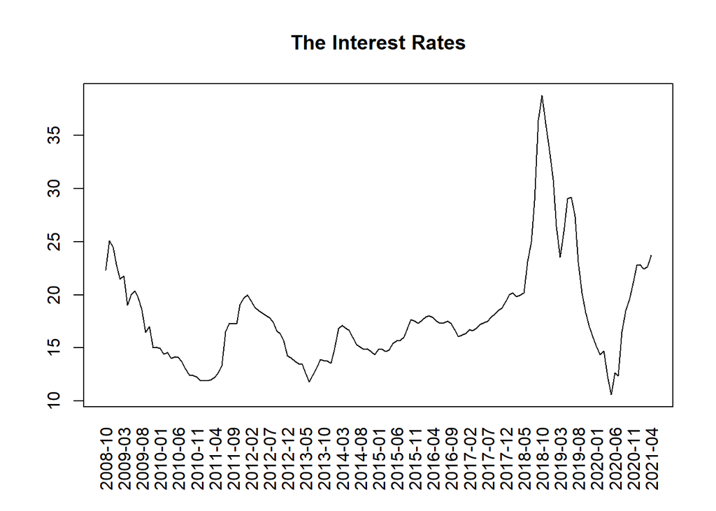

```r
cons_int <- unlist(EVDS[4])
names(cons_int) <- NULL
cons_int <- as.numeric(cons_int[-(152:181)])

setwd("C:/Users/Ezgi-Pc/Desktop")
google_int <- read.csv(file = 'google_int.csv')

plot(cons_int, type = "l", xaxt = "n", xlab = " ", ylab = " ", main = "The Interest Rates")
axis(side = 1, labels = x_axis, at = 1:151, tick = FALSE, las = 2)
```

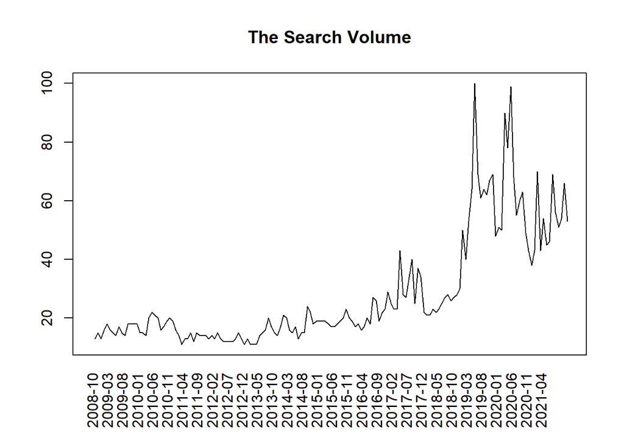

```r
plot(google_int, type = "l", xaxt = "n", xlab = " ", ylab = " ", main = "The Search Volume")
axis(side = 1, labels = x_axis, at = 1:151, tick = FALSE, las = 2)
```

Until 2018, the interest rates are a bit volatile but after the peak, it becomes much more volatile than before, which is actually reflected on the search volume plot. Like USD/TRY exchange rate case, although big increases or decreases in the interest rates may result in some increases in the search volume of the word *faiz*, the peaks in the search volume are seen with another peak and the enormous decrease afterwards in the interest rates and the search volume stays above a certain level after those peaks.

## 3. Consume Price Index (CPI)

Although inflation is not essentially an unwanted thing in an economy, the inflation in Turkey is always above the target rate and as a country which imports a lot, the prices of our everyday consumptions mostly depend on the exchange rates. Hence, I chose the CPI as my third data series.

The keyword I used for this data series is *enflasyon*. As the change in CPI level shows itself in our lives almost immediately, I wanted to see how much people were interested in checking the inflation level after experiencing a significant price increase.

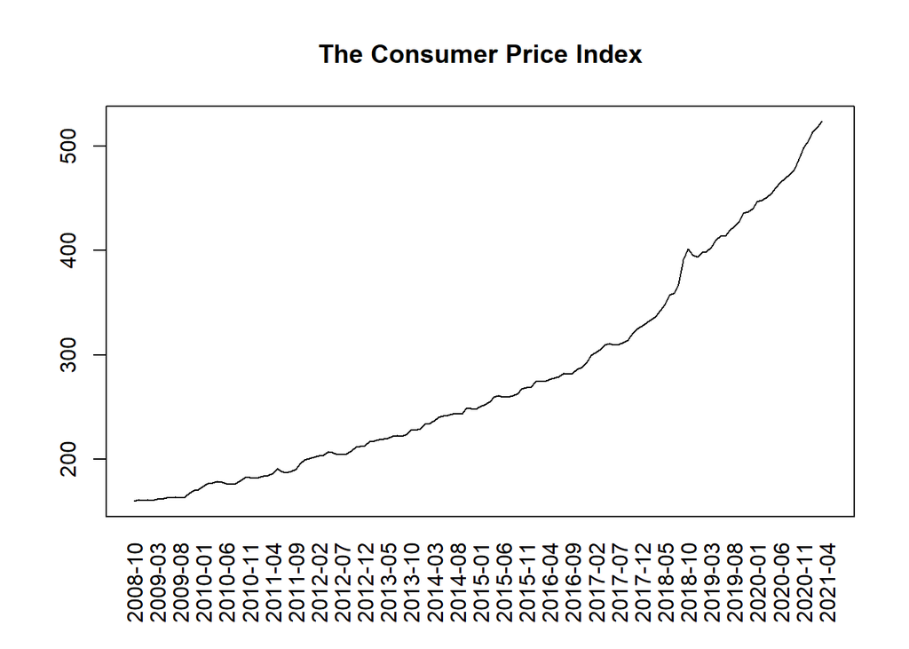

```r
cpi <- unlist(EVDS[6])
names(cpi) <- NULL
cpi <- as.numeric(cpi[-(152:181)])
setwd("C:/Users/Ezgi-Pc/Desktop")
google_inf <- read.csv(file = 'google_inf.csv')

plot(cpi, type = "l", xaxt = "n", xlab = " ", ylab = " ", main = "The Consumer Price Index")
axis(side = 1, labels = x_axis, at = 1:151, tick = FALSE, las = 2)
```

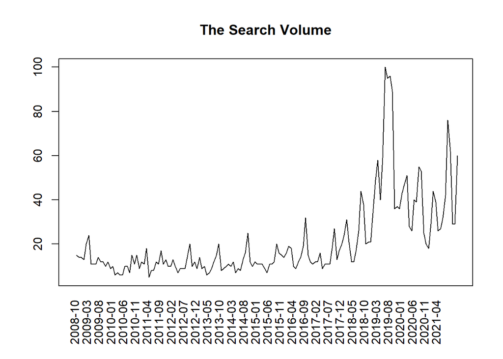

```r
plot(google_inf, type = "l", xaxt = "n", xlab = " ", ylab = " ", main = "The Search Volume")
axis(side = 1, labels = x_axis, at = 1:151, tick = FALSE, las = 2)
```

It can be seen above that the consumer price index of Turkey increases in an increasing way. Although there are certain increases in the search volume, the peak is again not until there is an unusual increase in the CPI. That is, people searched the word *enflasyon* when the inflation rate was unusually high. After that peak, the CPI continues to increase a bit faster than before, which is partly reflected on the search volume plot as after the peak, it is much more volatile than before as people kind of got used to the increase of CPI but still felt the need for checking inflation level time to time.